# State Unemployment Rates Analysis

MSDS 597 Final Project Report - Fall 2016

Shiqin Cai

December 6, 2016

### Abstract

State unemployment rate refers to the proportion of employable people in a state’s workforce who are over the age of 16 and who have either lost their jobs or have been actively seeking for jobs without success. There are many factors affecting the unemployment rate of a state, such as economic development, educational attainment, demographics, minimum wage and so on.

In this project, two factors, educational attainment and race, are considered to be correlated with unemployment rates. And the purpose of this project is to find the correlation between state unemployment rates and educational attainment, and the correlation between state unemployment rates and race using data cleaning, manipulation, and data visualization techniques. At the end of this project, the results are compared with the trends of national unemployment rates by educational attainment and by race in the past ten years. In addition, an Shiny App is built to demonstrate this project.

### Data Sources

Three main data sets including state unemployment rates, state educational attainment and state demographics are used to analyze the correlation between unemployment rates and educational attainment, and the correlation between unemployment rates and race.

The first data set `state unemployment rates` is collected from National Conference of State Legislatures(NCSL) using web-scraping. The second data set `state educational attainment` is also collected by web-scraping from the Wikipedia page. The `df_state_demographics` data set is extracted directly from the `choropleth` package in R.

At last, the national unemployment rates by educational attainment and by race data sets downloaded from Bureau of Labor Statistics(BLS) are used to compare with the correlations found.

### State Unemployment Rates / State Educational Attainment / State Demographics

#### State Unemployment Rates

The following table shows the state unemployment rate in the U.S. in October 2016 (seasonally adjusted). Since there are two `State` columns and two `Rate` columns, but I want one column for each variable.

```
##        State Rate         State Rate
## 1    Alabama  4.5       Montana  3.9
## 2     Alaska  7.0      Nebraska  2.8
## 3    Arizona  5.1        Nevada  4.8
## 4   Arkansas  3.4 New Hampshire  2.8
## 5 California  4.8    New Jersey  4.2
## 6   Colorado  2.4    New Mexico  6.3
```

So I split the data frame into two and combine them by rows. In order to use choroplethr, I convert the state names to lowercase. The tidy data frame is shown as below.

```
##          State Rate
## 1      alabama  4.5
## 2       alaska  7.0
## 3      arizona  5.1
## 4     arkansas  3.4
## 5   california  4.8
## 6     colorado  2.4
## 7  connecticut  5.0
## 8     delaware  4.8
## 9         d.c.  6.4
## 10     florida  4.1
```

The top 5 states with the lowest unemployment rates are:

```
##           State Rate
## 1  north dakota  2.2
## 2      colorado  2.4
## 3        hawaii  2.7
## 4      nebraska  2.8
## 5 new hampshire  2.8
```

The top 5 states with the highest unemployment rates are:

```
##         State Rate
## 1 puerto rico  9.8
## 2      alaska  7.0
## 3        d.c.  6.4
## 4  new mexico  6.3
## 5    kentucky  5.3
## 6   louisiana  5.3
```

The following state choropleth map shows the state unemployment rates in October 2016.

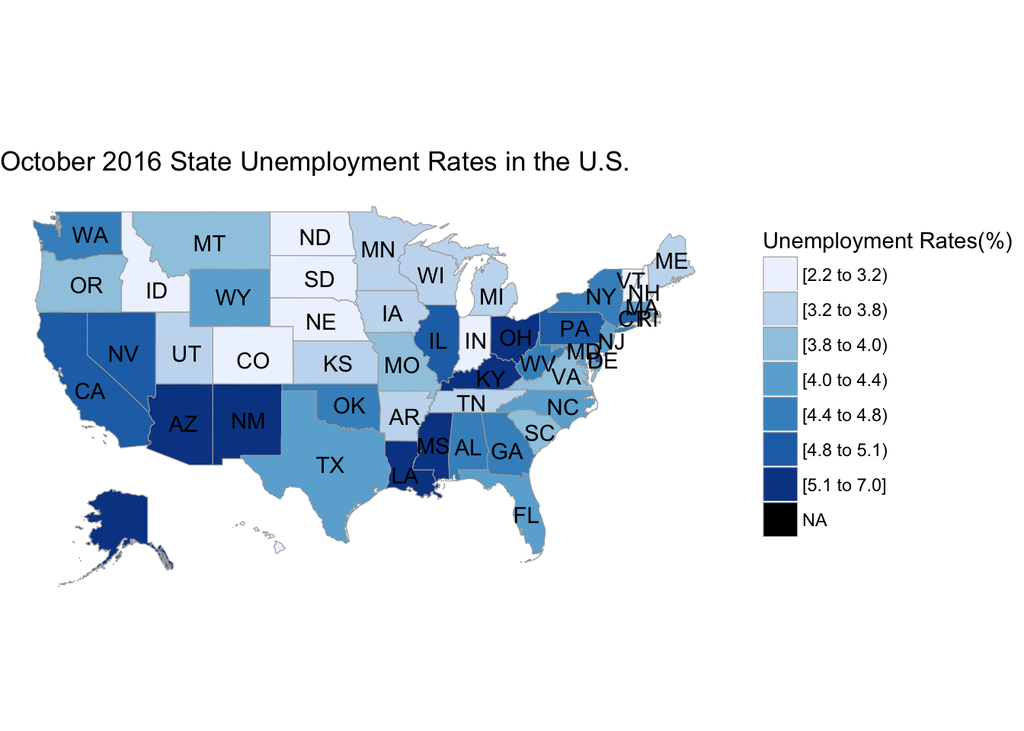

#### Educational Attainment

The following table shows the percentage of educational attainment by states.

[output not shown]

Since values in the columns `% High school graduate`, `% Bachelor's degree` and `% Advanced degree` are characters, I remove the `%` signs in these columns and convert them into numerical values. Moreover, only columns that I am interested in are kept, and the resulting tidy data frame is shown below. Again, I would like to use the tidy data to plot a choropleth map, so I change all state names to lower cases.

```
##            State High school graduate Bachelor's degree Advanced degree
## 1        montana                 92.8              29.5             9.5
## 2      minnesota                 92.4              33.7            11.2
## 3  new hampshire                 92.0              34.9            13.0
## 4        wyoming                 92.3              25.7             8.6
## 5         alaska                 92.1              28.0            10.1
## 6        vermont                 91.8              36.0            14.3
## 7   north dakota                 91.7              27.7             7.6
## 8          maine                 91.6              29.0            10.3
## 9           iowa                 91.5              26.7             8.5
## 10          utah                 91.2              31.1            10.4
```

The top 5 states with the highest high school graduate rates are:

```
##           State High school graduate Bachelor's degree Advanced degree
## 1       montana                 92.8              29.5             9.5
## 2     minnesota                 92.4              33.7            11.2
## 3 new hampshire                 92.0              34.9            13.0
## 4       wyoming                 92.3              25.7             8.6
## 5        alaska                 92.1              28.0            10.1
```

The top 5 states with the highest percentage of population who have a Bachelor’s degree are:

```
##                  State High school graduate Bachelor's degree
## 1             colorado                 90.7              38.1
## 2          connecticut                 89.9              37.6
## 3        massachusetts                 89.8              40.5
## 4             maryland                 89.4              37.9
## 5 district of columbia                 89.3              54.6
##   Advanced degree
## 1            14.0
## 2            16.6
## 3            17.7
## 4            17.3
## 5            31.3
```

The top 5 states with the highest percentage of population who have a advanced degree are:

```
##                  State High school graduate Bachelor's degree
## 1          connecticut                 89.9              37.6
## 2        massachusetts                 89.8              40.5
## 3             maryland                 89.4              37.9
## 4 district of columbia                 89.3              54.6
## 5             virginia                 88.3              36.3
##   Advanced degree
## 1            16.6
## 2            17.7
## 3            17.3
## 4            31.3
## 5            15.4
```

The choropleths maps below display the percentage of each educational level in all states.

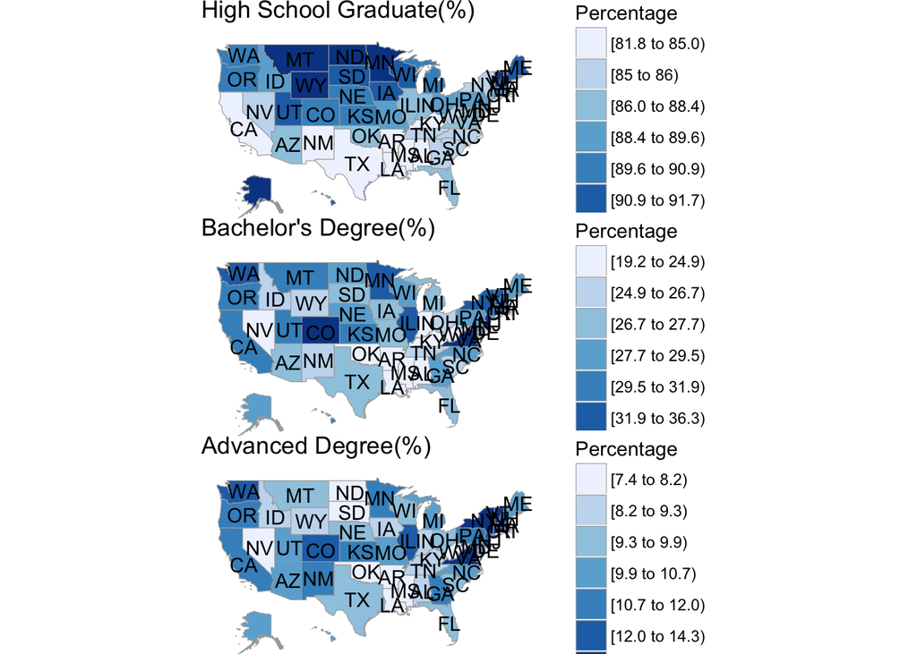

Comparing the state unemployment rates with state educational attainment, we see that New Hampshire has high `high school graduate` rate and low unemployment rate. Massachusetts has a high percentage of population with at least a Bachelor’s degree, and it has low unemployment rate. This shows that education matters. Education helps us to be more competitive in the job market. However, District of Columbia has a high percentage of population with at least a bachelor’s degree but still has a high unemployment rate.

```
##       State                Level Percentage
## 1   alabama High school graduate       84.3
## 2   alabama    Bachelor's degree       23.5
## 3   alabama      Advanced degree        8.7
## 4    alaska High school graduate       92.1
## 5    alaska    Bachelor's degree       28.0
## 6    alaska      Advanced degree       10.1
## 7   arizona High school graduate       86.0
## 8   arizona    Bachelor's degree       27.5
## 9   arizona      Advanced degree       10.2
## 10 arkansas High school graduate       84.8
```

The data frame above shows a transformation of the educational attainment data set from “wide” to “long”. This transformed data frame allows me to use the variable `Level` as an inputId for my shiny app which has radio button inputs with education level in the sidebar panel.

#### State Demographics

The following shows the state demographics data frame in the `choropleth` package in R, which is tidy. Only rows that I’m interested in are selected.

```
##       region total_population percent_white percent_black percent_asian
## 1    alabama          4799277            67            26             1
## 2     alaska           720316            63             3             5
## 3    arizona          6479703            57             4             3
## 4   arkansas          2933369            74            15             1
## 5 california         37659181            40             6            13
## 6   colorado          5119329            70             4             3
##   percent_hispanic
## 1                4
## 2                6
## 3               30
## 4                7
## 5               38
## 6               21
```

#### Joined Data Frame

In order to find out the correlations among unemployment rates, educational attainment and race, I merge the three data sets into one. Since `inner_join` only matches pairs of observations with the same key value, I would like to look at which observations are not matched while joining the three tidy data frames above.

```
##   State Rate
## 1  d.c.  6.4
```

```
##                  State High school graduate Bachelor's degree
## 1 district of columbia                 89.3              54.6
## 2        united states                 86.7              29.8
##   Advanced degree
## 1            31.3
## 2            11.2
```

From the results above, I notice that `d.c.` is the abbreviation of `district of columbia` but these two observations are not matched while joining the data sets `unemployment` and `education`. Hence, I change `d.c.` to `district of columbia` in the `unemployment` data frame, and inner join the data sets again. The combination of the three data frames is shown below:

```
##        State Rate High school graduate Bachelor's degree Advanced degree
## 1    alabama  4.5                 84.3              23.5             8.7
## 2     alaska  7.0                 92.1              28.0            10.1
## 3    arizona  5.1                 86.0              27.5            10.2
## 4   arkansas  3.4                 84.8              21.1             7.5
## 5 california  4.8                 81.8              31.4            11.6
## 6   colorado  2.4                 90.7              38.1            14.0
##   total_population percent_white percent_black percent_asian
## 1          4799277            67            26             1
## 2           720316            63             3             5
## 3          6479703            57             4             3
## 4          2933369            74            15             1
## 5         37659181            40             6            13
## 6          5119329            70             4             3
##   percent_hispanic
## 1                4
## 2                6
## 3               30
## 4                7
## 5               38
## 6               21
```

#### Unemployment rate vs Education

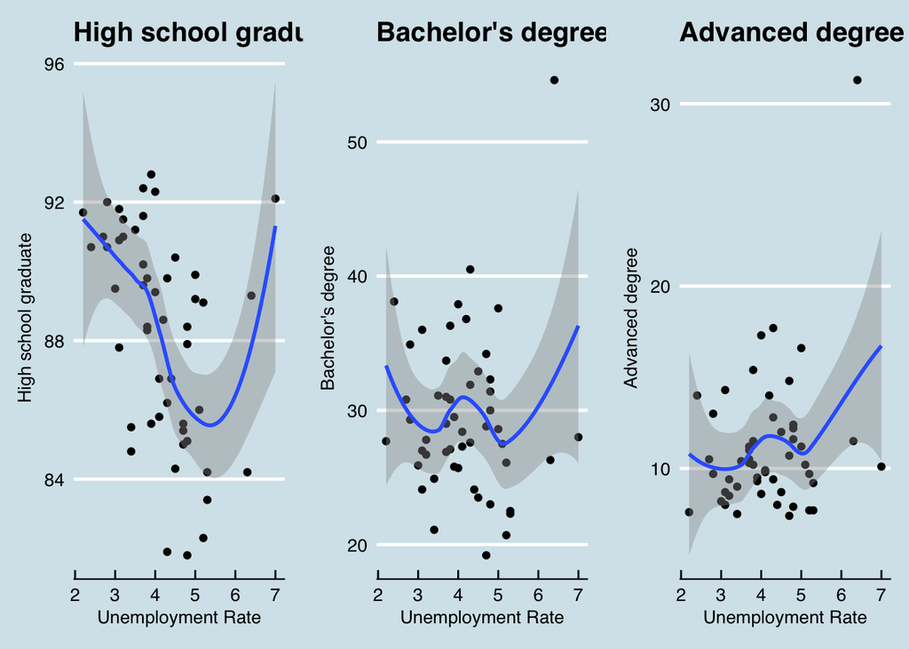

#### Unemployment Rate vs Race

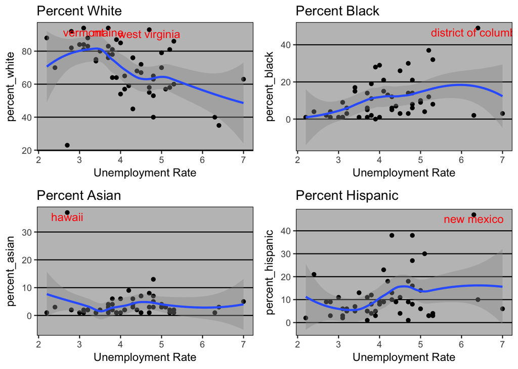

### Unemployemnt Rates by Educational Attainment

The data frame below is made up of four data sets downloaded from the Bureau of Labor Statistics. It shows the unemployment rates by educational attainment in the past ten years collected from Current Population Survey(CPS), or household survey.

```
##   Year Month Less_than_High_School High_School Some_College
## 1 2006   Jan                   7.0         4.4          3.6
## 2 2006   Feb                   7.1         4.4          3.6
## 3 2006   Mar                   6.9         4.1          3.7
## 4 2006   Apr                   6.9         4.4          3.8
## 5 2006   May                   7.0         4.3          3.8
## 6 2006   Jun                   7.1         4.1          3.5
##   Bachelor_and_Higher
## 1                 2.1
## 2                 2.2
## 3                 2.2
## 4                 2.2
## 5                 2.1
## 6                 2.1
```

In order to plot the unemployment rates against year and color by educational level, I first convert the data frame from “wide” to “long”. Then columns `Year` and `Month` are combined to one column and then are converted to time format. The resulting data frame is shown below.

```
##         Time     Educational_Level Unemployment_Rate
## 1 2006-01-01 Less_than_High_School               7.0
## 2 2006-01-01           High_School               4.4
## 3 2006-01-01          Some_College               3.6
## 4 2006-01-01   Bachelor_and_Higher               2.1
## 5 2006-02-01 Less_than_High_School               7.1
## 6 2006-02-01           High_School               4.4
```

From the ggplot below, we can see that in the past ten years, the unemployment rate of population whose educational level is lower than high school is highest. And the unemployment rate among those who have bachelor’s degree or higher degree is lowest. This also shows that the educational level is negatively correlated with unemployment rate, which is consistent with the result I got by just looking at the state unemployment rates and state educational attainment.

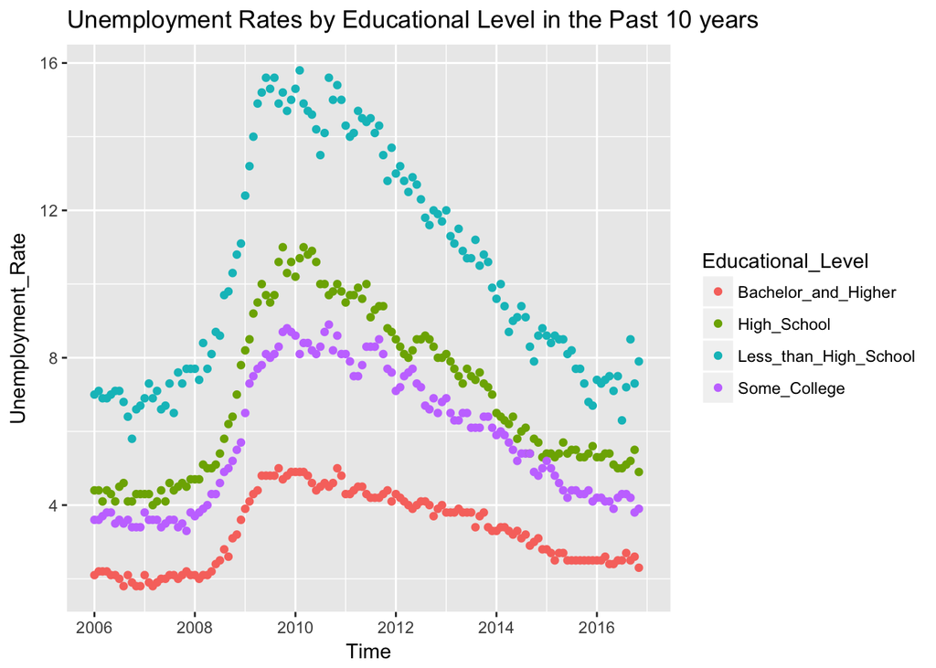

### Unemployment Rates by Race

The data frame below is also made up of four data sets downloaded from the Bureau of Labor Statistics. It shows the unemployment rates by race (White, Black, Asian and Hispanic) in the past ten years collected from Current Population Survey(CPS), or household survey.

```
##   Year Month White Black Asian Hispanic
## 1 2006   Jan   4.1   8.9   3.0      5.5
## 2 2006   Feb   4.1   9.5   3.0      5.4
## 3 2006   Mar   4.0   9.5   3.5      5.2
## 4 2006   Apr   4.1   9.4   3.9      5.5
## 5 2006   May   4.1   8.7   3.3      5.0
## 6 2006   Jun   4.1   8.9   3.1      5.2
```

In order to plot the unemployment rates against year and color by race, I first convert the data frame from “wide” to “long”. Then columns `Year` and `Month` are combined to one column and then are converted to time format. The resulting data frame is shown below.

```
##         Time     Race Unemployment_Rate
## 1 2006-01-01    White               4.1
## 2 2006-01-01    Black               8.9
## 3 2006-01-01    Asian               3.0
## 4 2006-01-01 Hispanic               5.5
## 5 2006-02-01    White               4.1
## 6 2006-02-01    Black               9.5
```

From the ggplot below, we can see that in the past ten years, the Black unemployment rate is the highest, Hispanic unemployment rate is the second highest, and White unemployment rate is lower than Black and Hispanic unemployment rate but is slightly higher than Asian unemployment rate. This also is consistent with the correlations I found.

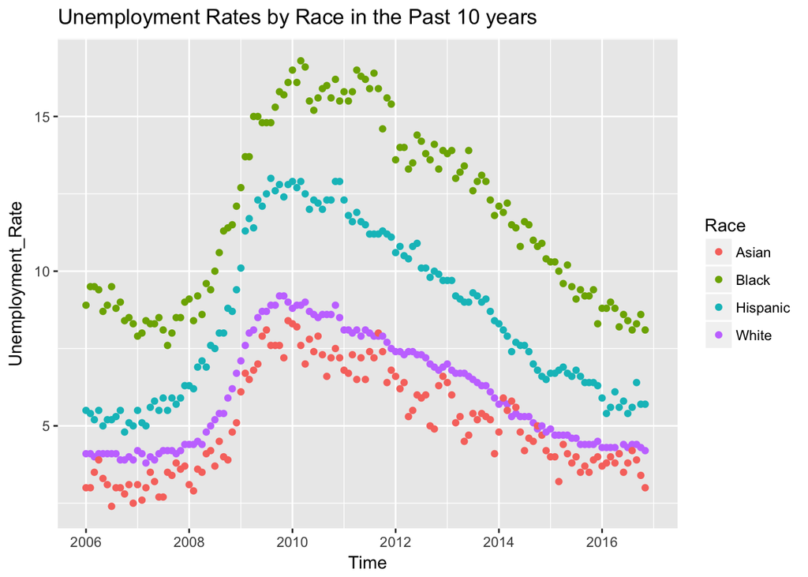

### Shiny App

https://caisq.shinyapps.io/myapp/

This UI displays the following things:

- state unemployment rates in a choropleth map in the bottom left panel,
- an interactive choropleth map with a tabset panel which shows state demographics in the main panel,
- an interactive map with radio buttons which allows users to select an educational level to view the state educational attainment, and
- a table generated from two states selected by users.

The layout in this UI allows us to visually compare three maps to see the correlations among educational attainment, race and unemployment rate. The table also provides data for users to compare two states.

In the future, I would like to make the map more interactive, so users can click on a state on the choropleth map to view the corresponding information such as educational attainment, demographics, and unemployment rate of the state. In addition, I will fit a statistical model to the unemployment rates against some factors and use the model to predict unemployment rate in the future.